# Analysis and Visualization Report

- Introduction
- Analysis and Visualization
- Conclusion

#### Introduction

This project involves all Data Wrangling Processes such as *Gathering*, *Assessing*, *Cleaning* and *Storing*. Analysis and Visualization are also done.

Three datasets were used, all containing data from a popular Twitter account WeRateDogs.

- The WeRateDogs Twitter archive. `twitter_archive_enhanced.csv`
- The tweet image predictions. `image_predictions.tsv`
- Additional data from the Twitter API. `tweet_json.txt`

#### Analysis and Visualization

I did Exploratory Data Analysi (EDA) using cleaned master dataset, *master_twitter* : `twitter_archive_master.csv` and the following were insights and visualization.

##### 1. Most popular dog_breeds

I performed analysis on dog breeds and plotted 20 most popular dog breeds

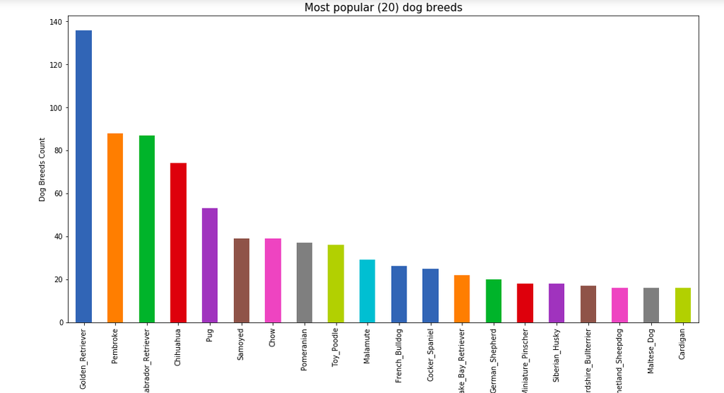

> From the graph above, it is evident that **Golden_Retriever** is the most popular dog breed

##### 2. Correlation between favorite_count and retweet_count

I analysed the relationship between favorite_count and retweet_count and plotted graph below.

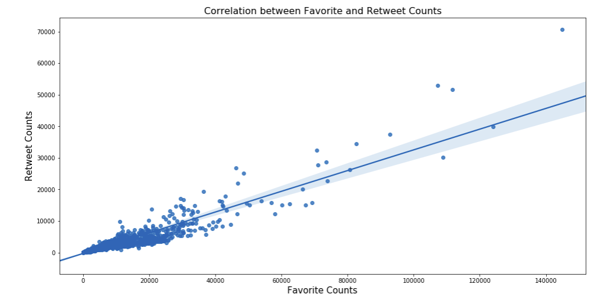

> From the graph above, we see that there is a **positive correlation** between Favorite and Retweet Counts. Therefore, an increase in favorite_count also means increase in retweet_count.

#### 3. Most popular dog_class

I analysed different dog classes and plotted graph as shown below.

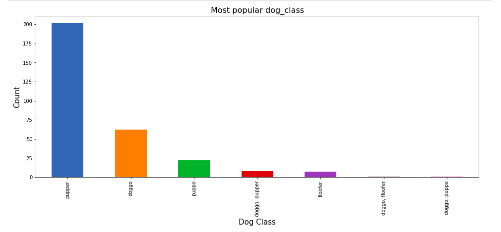

> From the graph above, we can observe that the most popular dogs class is **pupper**

> There are 7 dog classes where 4 classes are unique and 3 classes are multiple.

#### Conclusion

I successfully performed all Data Wrangling Processes, then did analysis and came up with 3 insights and visualizations.

### Lawrence OTIENO

##### Phone: +254708581688

##### Email: lawifirst@gmail.com